# The Sirius database

a dataset containing a sample of 900,000 international news articles published by 27 daily newspapers over a period of 354 weeks, from July 2013 to June 2020

Author

Claude Grasland

Published

2026-02-24

- **Keywords**: international relations; media studies; world; geography; countries; spatial analysis; network analysis.
- **Abstract**: Analysing the headlines and opening sentences of daily newspaper articles allows us to identify the list of foreign countries mentioned therein. This enables us to measure the flows between guest countries (those mentioned in the article) and host countries (where the newspaper is based). A sample of newspapers from different regions of the world thus forms a network of sensors that enables us to track, over time, the dynamics of the flows linking host countries and guest countries. This allows us, on the one hand, to analyse peaks of interest over time for certain guest countries. On the other hand, it enables us to compare how guest countries cover global news. The Sirius database, compiled using the open-access Mediacloud database, is one of the most diversified and equilibrated to date. It comprises 27 daily newspapers from 27 countries across five continents and covers seven years, from 1 July 2013 to 30 June 2020. All articles published by a newspaper were analysed using a dictionary to identify the countries mentioned in the language of publication (English, French, Spanish, Portuguese, Turkish, Persian, Indonesian, Russian, Arabic), and the country names were then converted into ISO 3 codes. We then randomly selected 100 international news articles per week for each newspaper. The database provides two types of files for each newspaper: (1) a list of geographically annotated articles; (2) an aggregated table showing the number of countries mentioned and country pairs, broken down by week of publication. A wide range of potential applications has been identified in both the social sciences (communication, geography, history, political science) and computer science (network analysis, signal theory).

## SPECIFICATION TABLES

**Subject**

Social Sciences

**Specific field**

International news flows theory and geopolitics of the contemporary world

**Data type**

The database consists of 54 tables saved in the compressed format of the statistical software R (.RDS), but which can be exported to .csv format for use with other software. Each of the 27 newspapers is described by 2 tables:

-**dt.RDS**: this file provides a sample of international news articles (title and opening sentences) published by a newspaper, with a maximum of 100 articles per week. It includes the date (when), the source (who), the text of the article (what) and the foreign countries mentioned (where) in the form of a list of ISO 3 codes

-**hc.RDS**: this file provides an aggregation of the places cited in the previous file in the form of a hypercube cross-referencing dates, sources, places and pairs of places, described by the number of corresponding articles in the form of raw frequency or fractions of news.

**Data collection**

The Mediacloud database provides access to news content published by a large number of newspapers around the world. Normally, only the headlines of news items can be obtained via the Mediacloud website. However, in 2020, the database’s creator allowed us to analyse the opening sentences as well, i.e. the news summaries that are usually included in RSS feeds. Using various country dictionaries compiled by us or by other researchers specialising in the analysis of international news feeds, we were able to extract a list of the countries mentioned in the headlines or descriptions of the news items.

**Location of the data source**

Those interested in the primary source of our database (namely the news headlines) will find it on the [MediaCloud project website](https://search.mediacloud.org/). The specific objectives of the Sirius project and a detailed presentation of the 27 newspapers selected is available on the [website of the Sirius project](https://worldregio.github.io/sirius/index.html).

**Data accessibility**

A stable version of the database at the date of submission of the article in Data in Brief has been released on the Harvard Dataverse

Repository name: Replication data for the Sirius project

Data identifier: https://doi.org/10.7910/DVN/OP8XTZ

Direct URL to the data: https://doi.org/10.7910/DVN/OP8XTZ

Furter development version will be made availale through the [github repository of the Sirius project](https://worldregio.github.io/sirius/) where it is possible to download the latest version of dictionnaries used for countries recognition and some basic programs of exploration.

**Related research article**

None at present. Various articles are in preparation.

## VALUE OF THE DATA

- **To support research in the field of communication and media studies concerning the International News Flow Theory (INFT)**. This field of research, established sixty years ago by Galtung and Ruge (1965) and Östgaard (1965), proposes to analyse the patterns governing the coverage of foreign countries in the media. Initially limited to the analysis of a small sample of news items over short periods, this field of research has benefited from the exploration of a broader set of newspapers, in particular by Wu (Wu (1998),Wu (2000),Wu (2003),Wu (2007)) and later Segev (Segev (2010), Segev (2014), Segev (2016), Segev (2017)) . Unlike large databases such as GDELT, which are compilations of heterogeneous sources, the Sirius project offers a sample of news selected by journalists and published by quality newspapers. The 27 media have been carefully sampled on a geographical basis in order to provide an accurate picture of the diversity of perspectives all around the World.
- **To suppor research in geopolitics and political science on the regionalisation of the world through information flows**. Media interest in events varies by newspaper location and is certainly not universal according to Hafez (2007). Newspapers located in the same country generally share a similar geopolitical agenda. But the Sirius database offers an opportunity to explore similarities among media outlets in 27 countries worldwide. The Sirius database, for example, allows us to analyse whether coverage of foreign news differs between countries in the North and those in the South, or whether it is organised by region, language or culture.
- **To provide a testing ground for analysing the dynamics of complex networks across space and time**. Indeed, the news items have been carefully sampled (100 international news articles per media outlet per week). The Sirius database can be easily used for empirical and theoretical experiments in statistical network analysis through two complementary approaches. Direct links between host countries (where the media outlet is based) and guest countries (mentioned in the news items). Indirect links between two guest countries are mentioned in the same news item by a host country acting as a third party.

## CONTEXT

The creation of global databases describing the dissemination of foreign news initially drew on a selection of major newspapers, generally based in Western countries, with a particular focus on English-language media such as The New York Times and The Guardian*, to which other media outlets from Western were subsequently added, such as Le Monde, El País, Die Zeit and The Asahi Shimbun… Due to the predominance of the same news providers (Reuters, AP, AFP), these corpora suggested the existence of a global public opinion. But research in the field of international news flow theory has demonstrated that these hypothesis of media globalisation is a myth (Hafez 2007) and that the international agenda remains strongly influenced by historical legacy, language barriers and geographical distance (Grasland 2019).

Currently, many researchers have attempted to overcome this problem by exploring increasingly large databases collected from the internet and by combining data from a wide range of sources (online media, social media, etc.), thereby producing vast collections such as Google News or the GDELT event database . But as Hong et al. (Hong et al. 2025) have pointed out, these gigantic databases suffer from a high level of redundancy and favour the views of the largest producers, introducing a sampling bias in global geographical coverage and an obvious bias in favour of the North over the South. The Sirius database, on the other hand, proposes selecting a limited number of high-quality newspapers, enriched within a national context, that more accurately reflect their readers’ interests.

## DESCRIPTION OF THE DATA

Table1: list of media contained in the Sirius Database

[output not shown]

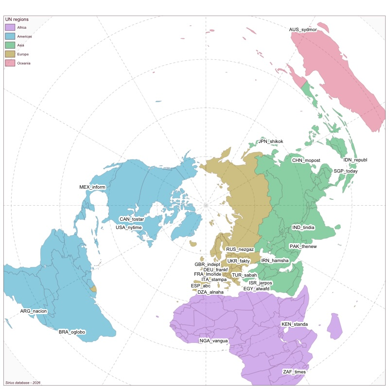

Figure 1 : Localisation of media contained in the Sirius Database

Based on these criteria, we selected 27 newspapers from the collections received in January and July 2020 that met the objective, even though some did not achieve the 100% coverage target for foreign news during the 350 weeks of the analysis period (Figure 2). This was in particular the case for the media received in January 2020, but not updated in July 2020.

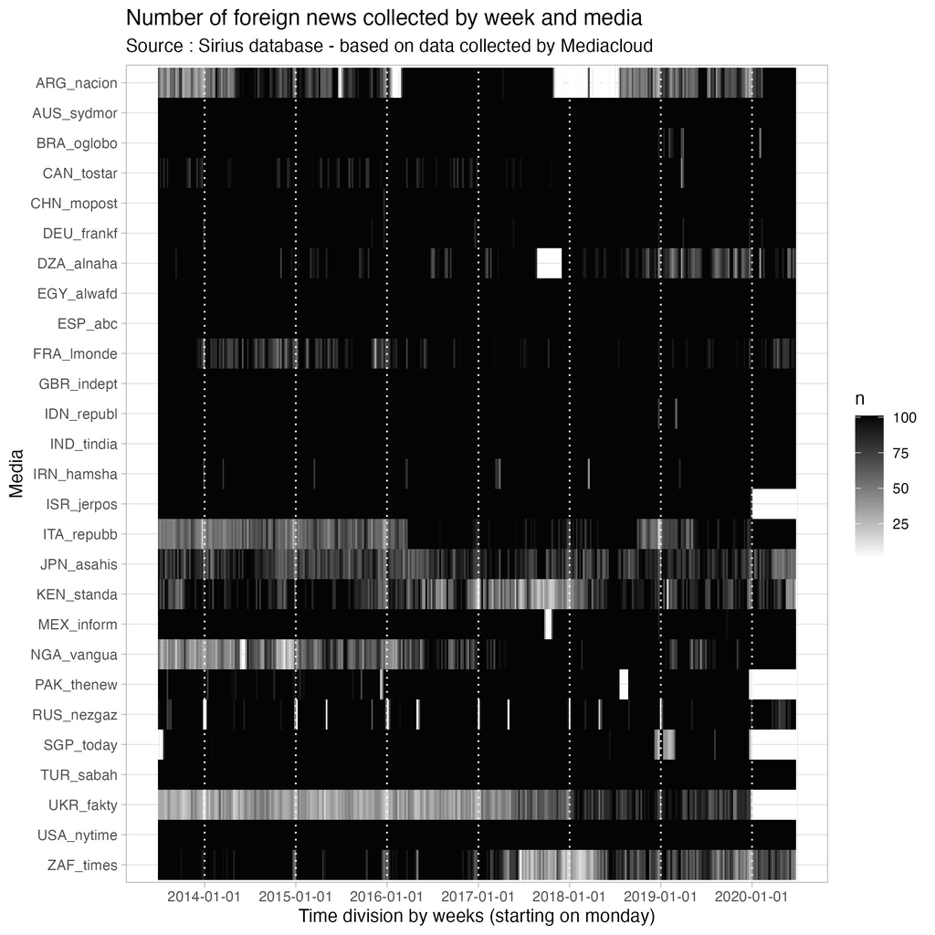

Figure 2 : Number of foreign news contained in the Sirius Database by media and week

The resulting database is organised into 27 folders, each named after the newspaper code (e.g., FRA_lmonde). In each folder, the user will find two files in compressed R format (.RDS), which are easy to convert into text files (.csv).

### Table of international news items annotated by country (**dt_int.RDS**)

This file is a table containing international news items from the newspapers, along with their source (who), publication date (when), a concatenation of the headline and the first few sentences used (text), the number of tokens (nbt), the list of foreign countries identified (states) and the length of this list (nbstates). The structure is illustrated by four examples of news items published in journal with different languages in Table 2.

Table 2 : example of news annotated by ISO3 code of countries mentionned in title and description

| when | who | text | states |
| --- | --- | --- | --- |
| 2018-10-16 | JPN_asahis | 中国軍、南シナ海でタイ・マレーシアと演習 米国に対抗 . | CHN THA MYS USA |
| 2016-05-20 | RUS_nezgaz | Госсекретарь: Бельгия против отмены виз ЕС с Турцией, Украиной, Грузией и Косово | BEL TUR UKR GEO KOS |
| 2016-02-16 | EGY_alwafd | اتفاق السعودية وروسيا وقطر وفنزويلا على تجميد إنتاج النفط.. وإيران تتحفظ . اتفقت السعودية وروسيا وقطر وفنزويلا، بعد اجتماع وزارى فى الدوحة اليوم، على تجميد إنتاجها من النفط عن | SAU RUS QAT VEN IRN |
| 2013-12-12 | NGA_vangua | Nigeria, Ghana… others to benefit from Microsoft student advantage . About seventeen African countries including Senegal, Ghana, Ivory Coast, Nigeria, Cameroon, Kenya, A | GHA SEN CIV CMR KEN |

The reader is probably unable to understand the text in all languages without the help of a translation. But the list of states mentionned in ISO3 code make possible to compare the geographical coverage of foreign news even if we ignore the exact content. The column states can be therefore considerd as a form of universal geographical Esperanto … In the examples chosen,it is clear that the coverage is strongly related to the regional location of the media.

### Hypercube of salience and links between the states mentioned in foreign news (**hc_int.RDS**)

This second file removes the text and focuses on the associations between countries mentioned in the same news items. The first column (*who*) indicates the newspaper, and the second column (*when*) indicates the first day of the week on which the data was collected. The columns *where1* and *where2* indicate the ISO3 code of the country pair mentioned in the news. The tags column indicates the absolute number of occurrences of countries or pairs, and the news column indicates the corresponding weight as a fraction of news (*see above for a detailed explanation*).

Table 3: Extract from and hypercube describing the salience and links between foreign states

| who | when | where1 | where2 | tags | news |
| --- | --- | --- | --- | --- | --- |
| IDN_republ | 2018-04-09 | RUS | RUS | 9 | 4.22 |
| IDN_republ | 2018-04-09 | RUS | SYR | 5 | 0.97 |
| IDN_republ | 2018-04-09 | RUS | USA | 2 | 0.22 |
| IDN_republ | 2018-04-09 | SYR | RUS | 5 | 0.97 |
| IDN_republ | 2018-04-09 | SYR | SYR | 22 | 8.65 |
| IDN_republ | 2018-04-09 | SYR | USA | 7 | 1.15 |
| IDN_republ | 2018-04-09 | USA | RUS | 2 | 0.22 |
| IDN_republ | 2018-04-09 | USA | SYR | 7 | 1.15 |
| IDN_republ | 2018-04-09 | USA | USA | 17 | 10.26 |

The example presented in Table 3 is an extract from the hypercube of the Indonesian newspaper *Republika* for the week beginning Monday, 9th April 2018, which marked a turning point in the Syrian civil war. The United States, France and the United Kingdom carried out a series of military strikes involving aircraft and missiles launched from ships against several government sites in Syria. These strikes were in response to the chemical attack on civilians in Douma on 7 April, widely attributed to the Syrian government. Russia protested at the UN, and there was a risk of conflict with the Russian navy stationed at the port of Tartus. The column tags indicate that out of 100 articles collected, 22 mentioned Syria, 17 the United States and 9 Russia. Concerning the dyads, 7 articles mentioned both the United States and Syria, 5 mentioned Russia and Syria, and 2 mentioned the United States and Russia. The column weights propose a different measure of salience, in which the importance of a country is proportional to the fact that it is mentioned alone and reduced when associated with other countries (*see. supra*). It indicates a higher weight for the United States (10.26) than for Syria (8.65), as Syria was more frequently associated with other countries in dyads or triads than the United States, which was mentioned alone in many articles.

Using only the where1 column, we can easily aggregate the hypercube to produce maps of the most frequently mentioned foreign countries. But using jointly both the where1 and where2 columns we can produce a weighted network of foreign countries associated in the same news. Figure 3 provides a visualisation example for the Indonesian newspaper Republika for the week of 9–15 April 2018 of the country that was the most mentioned (left) or the most linked to others (right)

*Figure 3 : Example of visualisation of hypercube data*

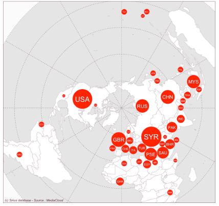

(a) map of foreign countries

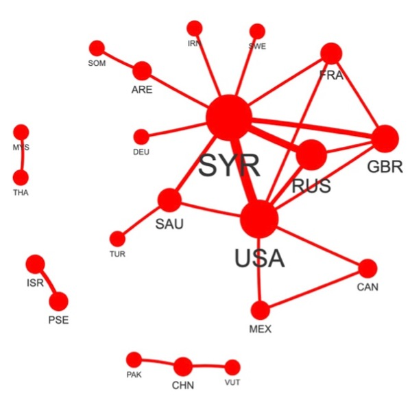

(b) network of foreign countries

We do not comment on this result as it is not the purpose of a data article. Still, the reader can easily imagine the potential applications of this approach for a comparative analysis of the geopolitical agendas of media outlets located across the globe across space and time.

## EXPERIMENTAL DESIGN. MATERIALS AND METHODS

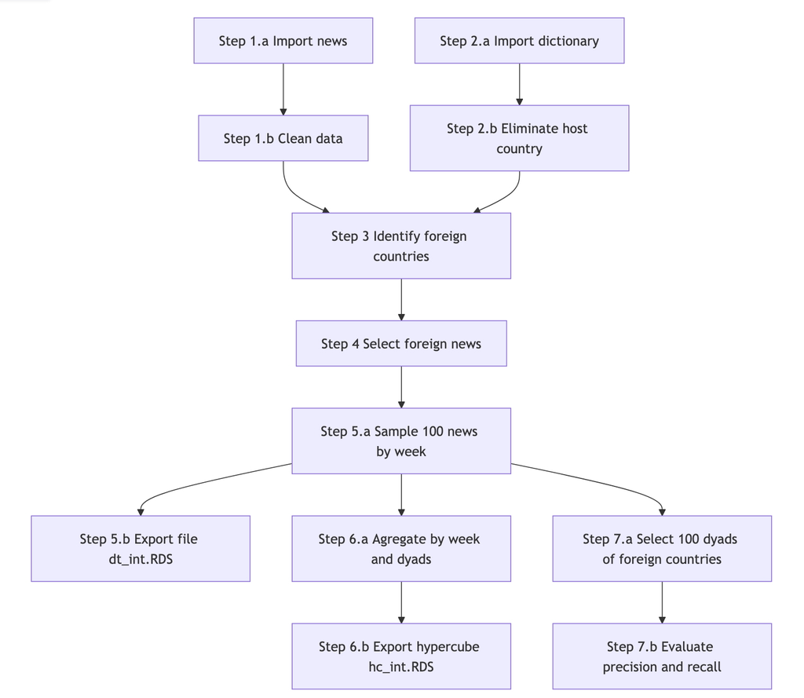

Figure 4 : Experimental design and methods for creating the Sirius database

### Steps 2 and 3: Identification of foreign news

For each language used in the newspapers, we have compiled a specific dictionary to identify the countries mentioned. In most cases, we compiled our dictionary using the newsmap package developed by Kohei Watanabe and other contributors, available on GitHubrepository . However, we decided to retain only country names and their grammatical variants, and to exclude demonyms or capital cities, as the aim of the Sirius database is not to recognise countries as geographical locations or political actors (an essential approach), but to recognise them solely as quasi-universal names that can be found in all languages and be associated to an ISO-3 code which plays the role of Rosetta stone. The aim of the Sirius database is indeed to analyse language games [14], defined as variations in the use and meaning of countries’ names in different contexts or different languages. This approach, based on Wittgenstein’s theory of language[15], [16] , rests on a strong assumption that the name of every country in the world exists in every language and can be converted into an ISO-3 code that will act as a sort of universal Esperanto.

The first obvious problem with this hypothesis is that there is no consensus on a list of ‘countries’. We could certainly start with the list of United Nations member states, as was done by Newsmap, but it is difficult to exclude semi-autonomous or disputed territories as long as they clearly play the same role as official states in current affairs. For example, we decided to include Hong Kong (HKG) and Macao (MAC) as recognised entities, since journalists treated them in the same way as states. However, we decided not to include Wales, Scotland, Northern Ireland and England, and to leave only the United Kingdom in the dictionary. We have included Greenland and Western Sahara in the dictionary because they cover vast areas where many events can take place. We have decided to put Gaza and the West Bank in a single entity associated with the Palestinian territories (PSE)… We acknowledge that all these choices can be criticised and are open to debate, and we can suggest that users of the Sirius database add or remove entities of their choice when using it. In total, we have identified 220 entities that are not necessarily ‘states’ in the legal sense, but which function as actors or locations in discourse.

The second problem with the hypothesis of a universal translation of state names is that it is difficult to limit translation to a single name in each language. Firstly, many languages add a prefix or suffix to the country’s name, which must be taken into account during recognition. In Arabic, the coordinating conjunction ‘and’ is translated by the letter wa (و), which is added to the following word as a prefix; thus, a news item beginning with ‘Egypt, Algeria and Tunisia’ would become ‘مصر وتونس والجزائر’. In German, country names may take a suffix when used in the Saxon genitive case, and a news item beginning with “The citizens of Belgium” might sometimes be translated as “Die Bürger von Belgien”, but more frequently as “Die Bürger Belgiens” with a suffix. In such cases, one might attempt to introduce a regular expression based on the root of the words (e.g. Belgien* or Belg*). Still, we have limited their use because it introduces a significant risk of false positives in the results.

The third issue concerns the political dimension of the choice of a country’s name, which we wanted to avoid with our nominalist approach but is, in fact, difficult to eliminate. For example, the name associated with the state of ‘Israel’ (ISR) can be translated into Persian as ‘اسرائیل’, but in most cases, the Iranian newspaper Hamshari prefers to use ‘نظام صهيونيستي’, which can be translated into English as ‘the Zionist regime’. Another difficulty concerns words associated with two geographical entities, such as the Arabic word المغرب, which can refer to either the state of Morocco (MAR) or the North African region known as the Maghreb. In this case, it is difficult to resolve the ambiguity without taking context into account.

The reader will probably suggest solving the problem by using AI or sophisticated linguistic models. However, these tools are difficult to apply to short text extracts (fewer than 100 tokens) and incur high computational costs for only a minor improvement in results. Another solution could be to translate all the news into English as the pivot language and use a single dictionary. But this solution also has an important ecological cost and destroys a large part of the initial information available in the native language, increasing the risk of errors. Here, we prefer to use a simpler gazetter method, with low computational cost and an acceptable error rate, as we shall see in step 7.

### Steps 4–5: Sampling 100 foreign news items per week

After identifying foreign news items with a limited risk of error (see step 7), we carry out a random sampling of 100 news items per week. The choice of a weekly sample is justified by the fact that all newspapers are characterised by a reduced production cycle at the weekend, with a minimum generally occurring on Saturdays and Sundays, but sometimes also on Fridays for religious reasons[17]. It may also be the case that certain newspapers specialise their content by day of the week and wait a few days before covering an event.

The main reason for this limitation to 100 articles per week and 36,500 for the entire observation period is to give equal weight to the different media outlets in the sample. The New York Times, for example, produced 1.8 million articles over this period, compared with 0.3 million for smaller newspapers. However, from a geographical and equitable sampling perspective, we wish to give equal weight to each in our sample, without introducing a complex weighting procedure at a later stage. And once again, we believe that high-quality research can be achieved with small, carefully selected samples rather than with a gigantic and heterogeneous database such as GDEL. And we must not forget the environmental cost of unnecessary use of computing time!

### Step 6: Construction of hypercubes by media, week and pairs of foreign states

Transforming the list of states into a hypercube is easily achieved using a data expansion and aggregation procedure in R. To illustrate the method, we take the example of three articles on the Syrian crisis published during the week of 9th April 2018 by the Indonesian newspaper Republika. Three foreign articles were selected, corresponding to a singleton, a dyad, and a triad (Table 4)

Table 4 : construction of hypercube : initial data

| id | when | who | text | states |
| --- | --- | --- | --- | --- |
| 1 | 2018-04-09 | IDN_republ | Haley: Tangan Rusia Berlumuran Darah Anak-Anak Suriah . , NEW YORK – Duta besar Amerika Serikat (AS) untuk PBB Nikki Haley mengatakan kepada | RUS SYR USA |
| 2 | 2018-04-09 | IDN_republ | AS Ancam Bom Suriah, Minyak Naik Level Tertinggi Sejak 2014 . , NEW YORK; – Harga minyak melonjak pada akhir perdagangan Rabu (Kamis pagi WIB | USA SYR |
| 3 | 2018-04-09 | IDN_republ | ACT Salurkan Bantuan Seribu Ton Beras untuk Suriah . ,; BANDA ACEH; – Lembaga kemanusiaan Indonesia Aksi Cepat Tanggap (ACT) ha | SYR |

We expand the dataset by the dimensions ‘when’ (week) and ‘who’ (media), as well as ‘where 1’ and ‘where 2’, corresponding to the list of states mentioned. We obtain an expanded table in which each news item is transformed into $n^2$ rows, where $n$ is the number of foreign states and ($1/n^2$) is the weight of the dyads based on the number of news items (Table 5).

Construction of the hypercube – expansion table

| id | who | when | where1 | where2 | wgt |
| --- | --- | --- | --- | --- | --- |
| 1 | IDN_republ | 2018-04-09 | RUS | RUS | 0.11 |
| 1 | IDN_republ | 2018-04-09 | RUS | SYR | 0.11 |
| 1 | IDN_republ | 2018-04-09 | RUS | USA | 0.11 |
| 1 | IDN_republ | 2018-04-09 | SYR | RUS | 0.11 |
| 1 | IDN_republ | 2018-04-09 | SYR | SYR | 0.11 |
| 1 | IDN_republ | 2018-04-09 | SYR | USA | 0.11 |
| 1 | IDN_republ | 2018-04-09 | USA | RUS | 0.11 |
| 1 | IDN_republ | 2018-04-09 | USA | SYR | 0.11 |
| 1 | IDN_republ | 2018-04-09 | USA | USA | 0.11 |
| 2 | IDN_republ | 2018-04-09 | USA | USA | 0.25 |
| 2 | IDN_republ | 2018-04-09 | USA | SYR | 0.25 |
| 2 | IDN_republ | 2018-04-09 | SYR | USA | 0.25 |
| 2 | IDN_republ | 2018-04-09 | SYR | SYR | 0.25 |
| 3 | IDN_republ | 2018-04-09 | SYR | SYR | 1.00 |

We can then proceed to aggregate the news items and create two columns, one relating to the sum of the weights, the other to the number of tags (Table 6)

Table 5: Construction of the hypercube – final result

| who | when | where1 | where2 | tags | news |
| --- | --- | --- | --- | --- | --- |
| IDN_republ | 2018-04-09 | RUS | RUS | 1 | 0.11 |
| IDN_republ | 2018-04-09 | RUS | SYR | 1 | 0.11 |
| IDN_republ | 2018-04-09 | RUS | USA | 1 | 0.11 |
| IDN_republ | 2018-04-09 | SYR | RUS | 1 | 0.11 |
| IDN_republ | 2018-04-09 | SYR | SYR | 3 | 1.36 |
| IDN_republ | 2018-04-09 | SYR | USA | 2 | 0.36 |
| IDN_republ | 2018-04-09 | USA | RUS | 1 | 0.11 |
| IDN_republ | 2018-04-09 | USA | SYR | 2 | 0.36 |
| IDN_republ | 2018-04-09 | USA | USA | 2 | 0.36 |

In our example, the reduction is not obvious, but it should be borne in mind that we have collected a random sample of 100 news items per week, many of which concern the same pairs of countries. Creating a hypercube will therefore significantly reduce the computational cost of in-depth analysis of country relevance or of network construction.

### Step 7: Estimating the accuracy and recall of foreign country recognition

For each of the 27 media outlets, we extracted a random sample of 100 news items containing two foreign countries from the dt_int.RDS table a random sample of 100 news items containing two foreign countries, and we manually checked the number of false positives (countries identified in error) and false negatives (countries that should have been identified but were not) to assess the precision and recall of the annotation procedure’s results (Table 6).

Table 6: Quality of foreign state identification in the 27 media of the Sirius database

| media | language | sample | tags | FP | FN | precision | recall | F-value |
| --- | --- | --- | --- | --- | --- | --- | --- | --- |
| DZA_alnaha | arabic | 100 | 200 | 5 | 15 | 0.975 | 0.929 | 0.951 |
| EGY_alwafd | arabic | 100 | 200 | 6 | 9 | 0.970 | 0.956 | 0.963 |
| AUS_sydmor | english | 100 | 200 | 3 | 5 | 0.985 | 0.975 | 0.980 |
| CAN_tostar | english | 100 | 200 | 0 | 7 | 1.000 | 0.966 | 0.983 |
| CHN_mopost | english | 100 | 200 | 1 | 8 | 0.995 | 0.961 | 0.978 |
| GBR_indept | english | 100 | 200 | 3 | 11 | 0.985 | 0.947 | 0.966 |
| IND_tindia | english | 100 | 200 | 1 | 5 | 0.995 | 0.975 | 0.985 |
| ISR_jerpos | english | 100 | 200 | 0 | 11 | 1.000 | 0.948 | 0.973 |
| KEN_standa | english | 100 | 200 | 2 | 8 | 0.990 | 0.961 | 0.975 |
| NGA_vangua | english | 100 | 200 | 4 | 3 | 0.980 | 0.985 | 0.982 |
| PAK_thenew | english | 100 | 200 | 6 | 3 | 0.970 | 0.985 | 0.977 |
| SGP_today | english | 100 | 200 | 4 | 5 | 0.980 | 0.975 | 0.978 |
| USA_nytime | english | 100 | 200 | 5 | 3 | 0.975 | 0.985 | 0.980 |
| ZAF_time | english | 100 | 200 | 3 | 6 | 0.985 | 0.970 | 0.978 |
| IRN_hamsha | farsi (persian) | 100 | 200 | 9 | 8 | 0.955 | 0.960 | 0.957 |
| FRA_lmonde | french | 100 | 200 | 0 | 9 | 1.000 | 0.957 | 0.978 |
| DEU_frankf | german | 100 | 200 | 0 | 11 | 1.000 | 0.948 | 0.973 |
| IDN_republ | indonesian | 100 | 200 | 4 | 1 | 0.980 | 0.995 | 0.987 |
| ITA_repubb | italian | 100 | 200 | 3 | 0 | 0.985 | 1.000 | 0.992 |
| JPN_shikok | japanese | 100 | 200 | 1 | 3 | 0.995 | 0.985 | 0.990 |
| BRA_oglobo | portuguese | 100 | 200 | 4 | 5 | 0.980 | 0.975 | 0.978 |
| RUZ_nezgaz | russian | 100 | 200 | 5 | 5 | 0.975 | 0.975 | 0.975 |
| UKR_fakty | russian | 100 | 200 | 3 | 0 | 0.985 | 1.000 | 0.992 |
| ARG_nacion | spanish | 100 | 200 | 5 | 8 | 0.975 | 0.961 | 0.968 |
| ESP_abc | spanish | 100 | 200 | 1 | 7 | 0.995 | 0.966 | 0.980 |
| MEX_infoma | spanish | 100 | 200 | 3 | 4 | 0.985 | 0.980 | 0.983 |
| TUR_sabah | turkish | 100 | 200 | 4 | 5 | 0.980 | 0.975 | 0.978 |
| Total |  | 2700 | 5400 | 85 | 165 | 0.984 | 0.970 | 0.977 |

It is important to note here that the manual verification of 2,700 news items and 5,400 countries was a lengthy but highly useful process that helped us correct numerous errors in the dictionaries and identify specific issues in the newspapers, such as the diversity of US abbreviations and the ambiguity of certain geographical names, such as ‘*Benin*’ and ‘*Niger*’ in Nigeria. The dictionaries made available on request by the author must not be used without a thorough examination of the text’s content and an ex ante cleaning procedure, followed by ex post quality control.

## LIMITATIONS

The Sirius database provides relatively good global coverage in terms of distribution across the various UN regions, with five media outlets in the Americas, five in Africa, five in Western Europe, five in Eastern Europe and the Middle East, and seven in Asia and Oceania, as shown in Figure 1. The balance between countries located in what is generally defined as the ‘Global North’ and the ‘Global South’ is maintained, with 11 countries clearly belonging to the West, 5 to the BRICS and 11 to what was historically defined as the Third World.

However, some important countries are missing, such as South Korea, for which data collection only began in 2018. The same problem arises for China, for which we have used the South China Morning Post, which is actually based in Hong Kong. Another issue concerns Africa, where the major countries in terms of economy and population are covered (Egypt, Algeria, Nigeria, Kenya, South Africa), but where smaller countries are overlooked, particularly the French-speaking countries of West Africa. This is a significant caveat, as the international agendas of French- and English-language media in Africa differ (Grasland 2026) .

## ETHICAL STATEMENT

The author has read and complies with the ethical requirements for publication in Data in Brief and confirms that this work does not involve human subjects, animal experiments or data collected from social media platforms.

## AUTHOR’S CRediT STATEMENT

Not applicable: sole author who carried out all the work presented in the article.

## ACKNOWLEDGEMENTS

This research did not receive any specific funding from public, commercial or non-profit funding bodies. We want to thank the members of the MediaCloud team for providing us with a special extract from their RSS feed database, containing news headlines and descriptions from January and July 2020. This open database, which has recently been updated, can still be used to supplement and expand upon this research (Roberts et al. 2021). We would also like to thank Kohei Watanabe, the author and coordinator of Newsmap, who provided an initial dictionary for identifying the states mentioned in the news (Watanabe 2018). We would also like to thank Kenneth Benoit, who developed the R package quanteda for text analysis in political science (Benoit et al. 2018).

## DECLARATION OF CONFLICTS OF INTEREST

• The authors declare that they have no known financial conflicts of interest or personal relationships that could influence the work presented in this article.

## References

Benoit, Kenneth, Kohei Watanabe, Haiyan Wang, Paul Nulty, Adam Obeng, Stefan Müller, and Akitaka Matsuo. 2018. “Quanteda: An r Package for the Quantitative Analysis of Textual Data.” *J. Open Source Software* 3 (30): 774.

Galtung, Johan, and Mari Holmboe Ruge. 1965. “The Structure of Foreign News the Presentation of the Congo, Cuba and Cyprus Crises in Four Norwegian Newspapers.” *Journal of Peace Research* 2 (1): 6490. http://jpr.sagepub.com/content/2/1/64.short.

Grasland, Claude. 2019. “International News Flow Theory Revisited Through a Spacetime Interaction Model: Application to a Sample of 320,000 International News Stories Published Through RSS Flows by 31 Daily Newspapers in 2015.” *International Communication Gazette*, February, 1748048518825091. https://doi.org/10.1177/1748048518825091.

———. 2026. “The Diffusion of the Concept of ‘the Global South’ in the Press: The Case of Africa.” *Third World Quarterly* 47 (4): 834–48. https://doi.org/10.1080/01436597.2025.2597392.

Hafez, Kai. 2007. *The Myth of Media Globalization*. Polity.

Hong, Dengxi, Zexin Fu, Xin Zhang, and Yan Pan. 2025. “Research on the Development and Application of the GDELT Event Database.” *Data* 10 (10): 158. https://www.mdpi.com/2306-5729/10/10/158.

Östgaard, Einar. 1965. “Factors Influencing the Flow of News.” *Journal of Peace Research* 2 (1): 3963.

Roberts, Hal, Rahul Bhargava, Linas Valiukas, Dennis Jen, Momin M. Malik, Cindy Sherman Bishop, Emily B. Ndulue, Aashka Dave, Justin Clark, and Bruce Etling. 2021. “Media Cloud: Massive Open Source Collection of Global News on the Open Web.” In, 15:10341045. http://ojs.aaai.org/index.php/ICWSM/article/view/18127.

Segev, Elad. 2010. “Mapping the International: Global and Local Salience and News-Links Between Countries in Popular News Sites Worldwide.” *International Journal of Internet Science* 5 (1): 4871.

———. 2014. “Visible and Invisible Countries: News Flow Theory Revised.” *Journalism*, 1464884914521579.

———. 2016. *International News Flow Online. Global Views with Local Perspectives*. New York Bern Frankfurt Berlin Brussels Vienna Oxford Warsaw: Peter Lang.

———. 2017. “From Where Does the World Look Flatter? A Comparative Analysis of Foreign Coverage in World News.” *Journalism*, 1464884916688292.

Watanabe, Kohei. 2018. “Newsmap.” *Digital Journalism* 6 (3): 294–309. https://doi.org/10.1080/21670811.2017.1293487.

Wu, H. Denis. 1998. “Investigating the Determinants of International News Flow a Meta-Analysis.” *International Communication Gazette* 60 (6): 493512. http://gaz.sagepub.com/content/60/6/493.short.

———. 2000. “Systemic Determinants of International News Coverage: A Comparison of 38 Countries.” *Journal of Communication* 50 (2): 110130. http://onlinelibrary.wiley.com/doi/10.1111/j.1460-2466.2000.tb02844.x/abstract.

———. 2003. “Homogeneity Around the World? Comparing the Systemic Determinants of International News Flow Between Developed and Developing Countries.” *International Communication Gazette* 65 (1): 924. http://gaz.sagepub.com/content/65/1/9.short.

———. 2007. “A Brave New World for International News? Exploring the Determinants of the Coverage of Foreign News on US Websites.” *International Communication Gazette* 69 (6): 539551. http://gaz.sagepub.com/content/69/6/539.short.